# Homework #2

cuden

9/5/2018

## Typora & Thinking on Paper

This term I will be working with Jane Molofsky from the plant biology department. As we have only met once about the project, I only have a novice understanding. Having said that, organising my thoughts on paper and using typora is a good place to start.

### What is the big question being asked?

What stage of the Centaura (an invasive plant species) is most vulnerable to biological control? ie. elements of the transition matrix have high sennsativities/elasticities (biggest impact on lambda)?

### What are specific hypothese and mechanisms being explored?

The hypothesis here is that biological control will be most effective if highly sensative transitions are targeted.

### How will these results be interpreted?

High elasticity and sesativities indicate stages of the Centauea life cycle vulnerable to biological cotrol.

Below is a flow chart I made (using Typora) to get a clearer understanding of how Centaurea progresses through each stage of its life.

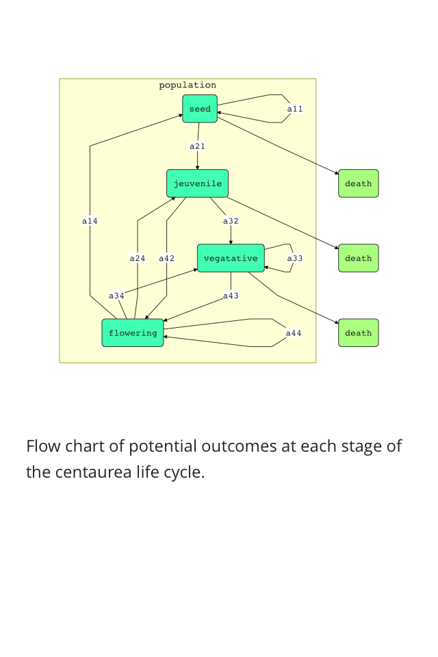

I also drew a sketch on paper of how the transitions will be organised into a matrix. Here is a picture of it:

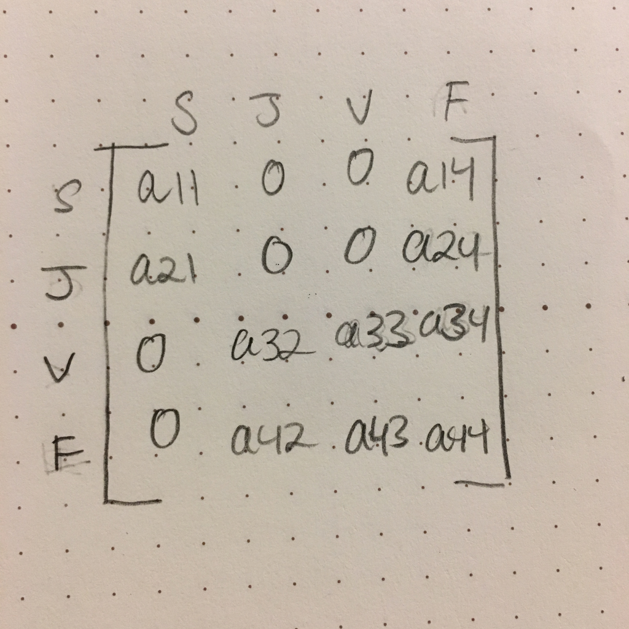

Eventually I will be building actual matrices for the data, so here is a “sketch” in R:

```r
stages <- c("seedling", "jeuvenile", "vegetative", "flowering")
A <- matrix(c("a11", 0, 0, "a14", "a21", 0, 0, "a24", 0, "a32", "a33", "a34", 0, "a42", "a43", "a44"), nrow = 4, byrow = TRUE, dimnames = list(stages, stages))
print(A)
```

```
##            seedling jeuvenile vegetative flowering
## seedling   "a11"    "0"       "0"        "a14"
## jeuvenile  "a21"    "0"       "0"        "a24"
## vegetative "0"      "a32"     "a33"      "a34"
## flowering  "0"      "a42"     "a43"      "a44"
```